# Lecture 3 Autocorrelation and Model selection

$${\textbf{Autocorrelation Function}}
\newcommand{\var}{\text{var}}
\newcommand{\cov}{\text{cov}}
\newcommand{\cor}{\text{cor}}$$

## Autocorrelation

Consider a time series $Y_t$

- Mean: $E(Y_t)=\mu_t$
- Variance: $\var(Y_t)$.

The **autocovariance** of $Y_t$ at lag $j$ is
$$\cov(Y_t,Y_{t-j}) = E[ \: (Y_t-\mu_t) \, (Y_{t-j}-\mu_{t-j}) \:]$$

## Autocorrelation

Consider a time series $Y_t$

- Mean: $E(Y_t)=\mu_t$
- Variance: $\var(Y_t)$.

The **autocorrelation** of $Y_t$ at lag $j$ is
$$\cor(Y_t, Y_{t-j}) = \frac{\cov(Y_t, Y_{t-j})}
{\sqrt{\var(Y_t) \: \var(Y_{t-j})}}$$

## Autocorrelations in data

For any $j$:
$$\widehat\cov(Y_t, Y_{t-j}) =
\frac{1}{n}\sum_{t=j+1}^n (Y_t-\widehat\mu_t) \
(Y_{t-j}-\widehat\mu_{t-j})$$
where typically
$$\widehat\mu_t = X_t'\widehat\beta$$

Note $\widehat\var(Y_t) = \widehat\cov(Y_t, Y_{t-j})$ with $j=0$.

## Autocorrelations in data

For any $j$:
$$\widehat\cov(Y_t, Y_{t-j}) =
\frac{1}{n}\sum_{t=j+1}^n \widehat{Z}_t
\widehat{Z}_{t-j}
\qquad\qquad\qquad\:\:\:$$
where $\widehat{Z}_t=Y_t-X_t'\widehat{\beta}$ are residuals from regression on trend, seasonals etc as appropriate.

## Autocorrelations in retail sales

```r
Y <- window(log(Retail_q), start=c(2000,1),
            end=c(2018,4))
Time <- time(Y)
gfc <- 2008.5
Time_postgfc <- 1*(Time>gfc)*(Time-gfc)
QD <- seasonaldummy(Y)
X <- cbind(Time, Time_postgfc, QD)
AR0 <- Arima(Y, order=c(0,0,0), xreg=X)
Z <- AR0$residuals
```

## Autocorrelations in retail sales

```r
Z <- AR0$residuals
acfZ <- acf(Z)
print(round(acfZ$acf[1:5],3))
```

```
[1] 1.000 0.730 0.619 0.379 0.258
```

## Autocorrelations in retail sales

```r
Z <- AR0$residuals
acfZ <- acf(Z)
print(round(acfZ$acf[1:5],3))
```

```
[1] 1.000 0.730 0.619 0.379 0.258
```

$\qquad\quad {\color{cyan}{\uparrow}}$

$\qquad {\color{cyan}{\cor(\widehat{Z}_t, \widehat{Z}_{t}) = 1}}$

$\qquad{\color{cyan}{\text{(obviously...)}}}$

## Autocorrelations in retail sales

```r
Z <- AR0$residuals
acfZ <- acf(Z)
print(round(acfZ$acf[1:5],3))
```

```
[1] 1.000 0.730 0.619 0.379 0.258
```

$\qquad\qquad\qquad {\color{cyan}{\uparrow}}$

$\qquad\qquad {\color{cyan}{\cor(\widehat{Z}_t, \widehat{Z}_{t-1}) = 0.730}}$

## Autocorrelations in retail sales

```r
Z <- AR0$residuals
acfZ <- acf(Z)
print(round(acfZ$acf[1:5],3))
```

```
[1] 1.000 0.730 0.619 0.379 0.258
```

$\qquad\qquad\qquad\qquad\quad {\color{cyan}{\uparrow}}$

$\qquad\qquad\qquad\quad {\color{cyan}{\cor(\widehat{Z}_t, \widehat{Z}_{t-2}) = 0.619}}$

## Autocorrelations in retail sales

```r
Z <- AR0$residuals
acfZ <- acf(Z)
print(round(acfZ$acf[1:5],3))
```

```
[1] 1.000 0.730 0.619 0.379 0.258
```

$\qquad\qquad\qquad\qquad\qquad\quad {\color{cyan}{\uparrow}}$

$\qquad\qquad\qquad\qquad\quad {\color{cyan}{\cor(\widehat{Z}_t, \widehat{Z}_{t-3}) = 0.379}}$

## Autocorrelations in retail sales

```r
Z <- AR0$residuals
acfZ <- acf(Z)
print(round(acfZ$acf[1:5],3))
```

```
[1] 1.000 0.730 0.619 0.379 0.258
```

$\qquad\qquad\qquad\qquad\qquad\qquad\quad\quad {\color{cyan}{\uparrow}}$

$\qquad\qquad\qquad\qquad\quad\quad {\color{cyan}{\cor(\widehat{Z}_t, \widehat{Z}_{t-4}) = 0.258}}$

## Autocorrelations in retail sales

```r
Z <- AR0$residuals
acfZ <- acf(Z)
```

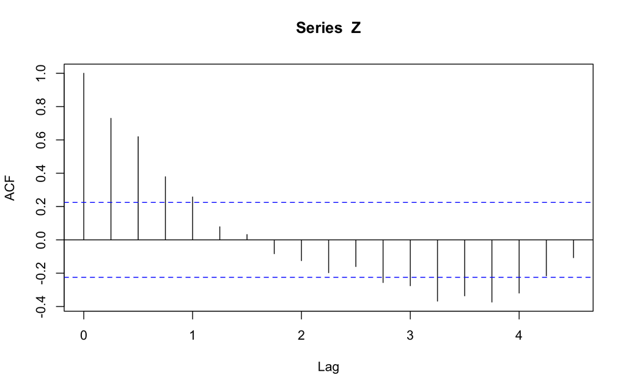

## Autocorrelations in retail sales

```r
Z <- AR0$residuals
acfZ <- acf(Z)
```

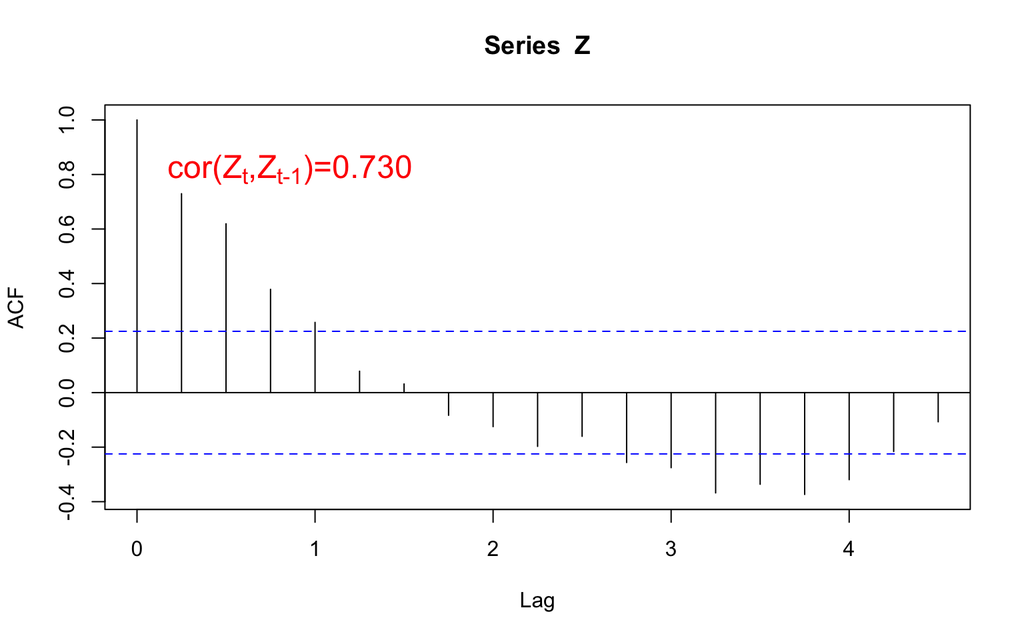

## Autocorrelations in retail sales

```r
Z <- AR0$residuals
acfZ <- acf(Z)
```

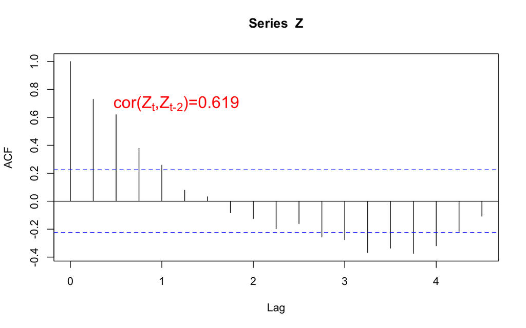

## Autocorrelations in retail sales

```r
Z <- AR0$residuals
acfZ <- acf(Z)
```

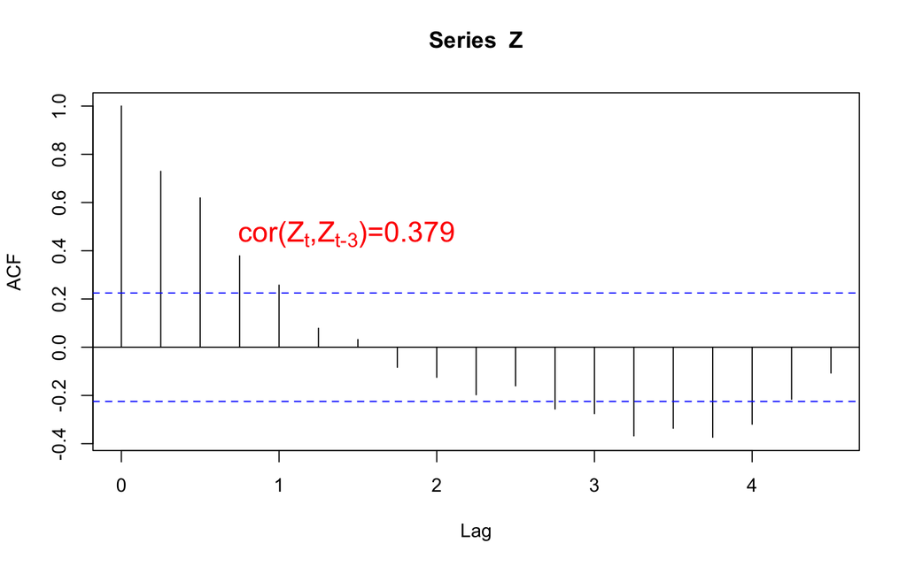

## Autocorrelations in retail sales

```r
Z <- AR0$residuals
acfZ <- acf(Z)
```

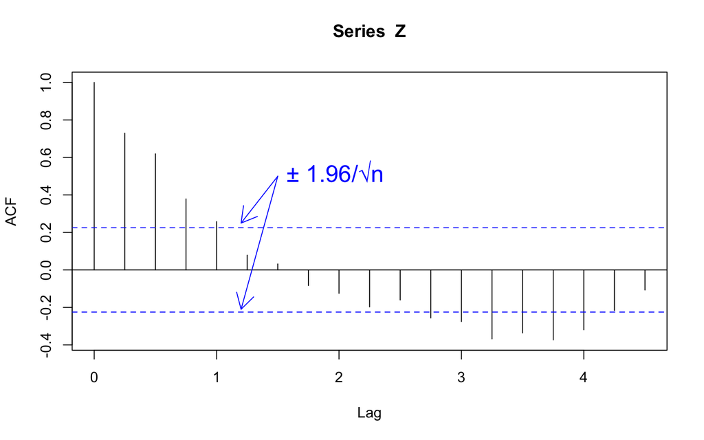

## Autocorrelations in retail sales

```r
Z <- AR0$residuals
acfZ <- acf(Z)
```

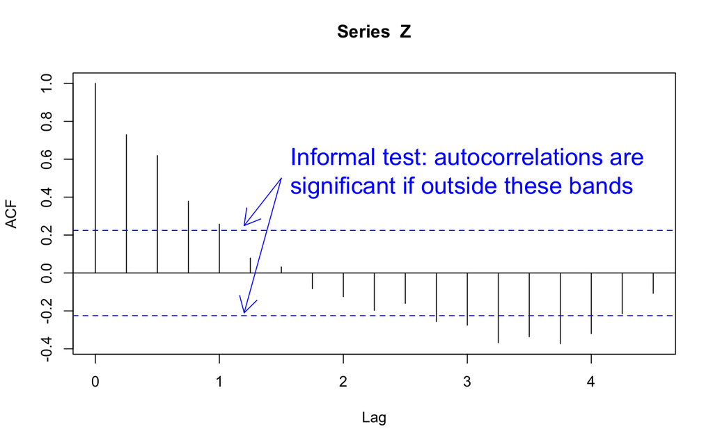

## A formal autocorrelation test

```r
checkresiduals(AR0)
```

```
    Ljung-Box test

data:  Residuals from Regression with ARIMA(0,0,0) errors
Q* = 92.465, df = 8, p-value < 2.2e-16

Model df: 0.   Total lags used: 8
```

## A formal autocorrelation test

Ljung-Box test statistic:
$$Q^* = n(n+2)\sum_{k=1}^{\color{lime}{l}} \frac{{\color{orange}{r_k}}^2}{n-k}$$

$\quad {\color{orange}{r_k}} = \widehat{\cor}(\widehat{Z}_t,\widehat{Z}_{t-k})$

$\quad {\color{lime}{l}}=\min(8,n/5)$ for quarterly data.

## A formal autocorrelation test

Ljung-Box test statistic:
$$Q^* = n(n+2)\sum_{k=1}^{\color{lime}{l}} \frac{{\color{orange}{r_k}}^2}{n-k}$$

$\quad H_0: \text{all autocorrelations are zero}$

$\quad H_1 : \text{at least one autocorrelation not zero}$

Reject $H_0$ for $p<0.05$, where the $p$-value for $Q^*$ uses a $\chi_{l-p}^2$ distribution.

## A formal autocorrelation test

```r
checkresiduals(AR0)
```

```
    Ljung-Box test

data:  Residuals from Regression with ARIMA(0,0,0) errors
Q* = 92.465, df = 8, p-value < 2.2e-16

Model df: 0.   Total lags used: 8
```

${\color{magenta}{\dfrac{}{\quad\quad\: \Rightarrow \: \text{reject } H_0 \:}}}$

## Why does autocorrelation matter?

Recall the one-step-ahead forecast errors
$$U_t = Y_t - E(Y_t | {\mathscr{F}}_{t-1})$$
satisfy $E(U_t | {\mathscr{F}}_{t-1}) = 0$, and hence
$$\cor(U_t, U_{t-k}) = 0 \text{ for every } k>0$$

${\color{orange}{\Rightarrow}}$ if residuals from a model are autocorrelated then that model is *misspecified* for the conditional expectation.

## A formal autocorrelation test

```r
checkresiduals(AR0)
```

```
    Ljung-Box test

data:  Residuals from Regression with ARIMA(0,0,0) errors
Q* = 92.465, df = 8, p-value < 2.2e-16

Model df: 0.   Total lags used: 8
```

${\color{magenta}{\dfrac{}{\texttt{AR0} \text{ is misspecified}}}}$

## AR(1) model

```r
AR1 <- Arima(Y, order=c(1,0,0), xreg=X)
checkresiduals(AR1)
```

```
    Ljung-Box test

data:  Residuals from Regression with ARIMA(1,0,0) errors
Q* = 15.822, df = 7, p-value = 0.02679

Model df: 1.   Total lags used: 8
```

${\color{magenta}{\dfrac{}{\texttt{AR1} \text{ is misspecified}}}}$

## AR(1) model

```r
AR1 <- Arima(Y, order=c(1,0,0), xreg=X)
checkresiduals(AR1)
```

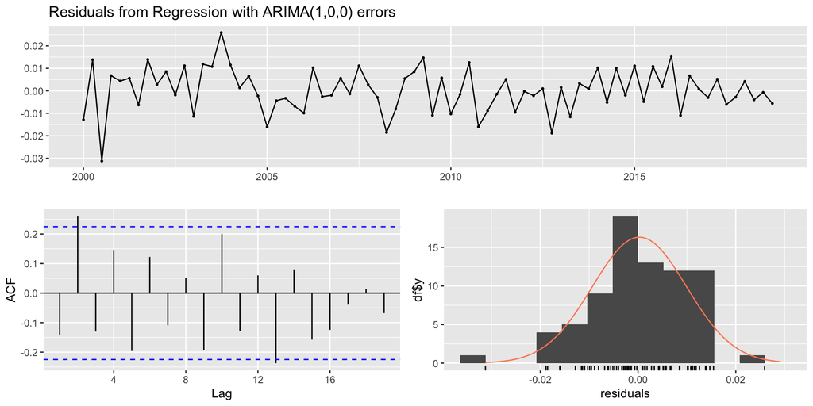

## AR(2) model

```r
AR2 <- Arima(Y, order=c(2,0,0), xreg=X)
checkresiduals(AR2)
```

```
    Ljung-Box test

data:  Residuals from Regression with ARIMA(2,0,0) errors
Q* = 7.5095, df = 6, p-value = 0.2763

Model df: 2.   Total lags used: 8
```

${\color{magenta}{\dfrac{}{\texttt{AR2} \text{ passes the test!}}}}$

## AR(2) model

```r
AR2 <- Arima(Y, order=c(2,0,0), xreg=X)
checkresiduals(AR2)
```

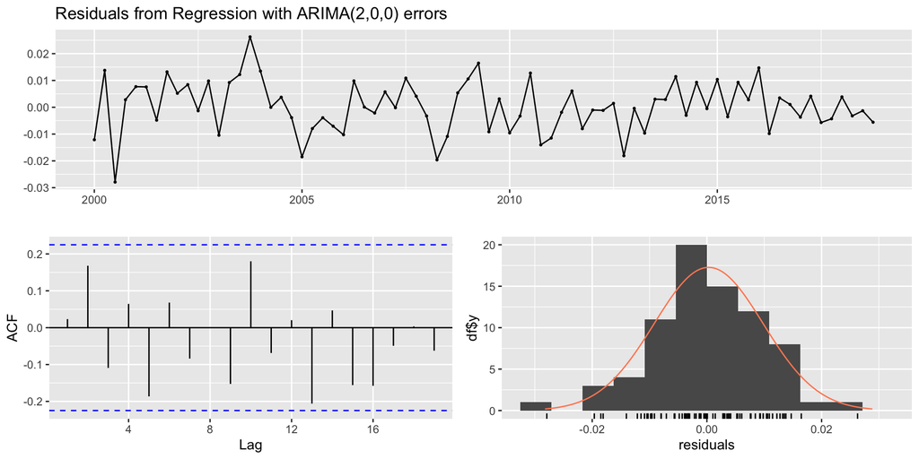

$${\textbf{Model selection}}
\newcommand{\var}{\text{var}}
\newcommand{\cov}{\text{cov}}
\newcommand{\cor}{\text{cor}}$$

## Akaike Information Criterion (AIC)

Consider a model $m(Y_{t-1},Y_{t-2},\ldots; \theta)$ of $E(Y_t|{\mathscr{F}}_{t-1})$.

Example. AR(*p*):
$$\begin{align}
m(Y_{t-1},&Y_{t-2},\ldots; \theta) \\
= & \theta_1 Y_{t-1} + \ldots + \theta_p Y_{t-p}
\end{align}$$

## Akaike Information Criterion (AIC)

Consider a model $m(Y_{t-1},Y_{t-2},\ldots; \theta)$ of $E(Y_t|{\mathscr{F}}_{t-1})$.

Define residuals
$$\widehat{U}_t = Y_t - m(Y_{t-1},Y_{t-2},\ldots; \widehat\theta)$$
and residual variance
$$\hat\sigma_U^2 = \frac{1}{n}\sum_{t=1}^n \widehat{U}_t^2.$$

## Akaike Information Criterion (AIC)

The AIC is
$$\text{AIC} = n \log(\hat\sigma_U^2) + 2 (M+1)$$
where $M$ is the number of parameters in $\theta$.

Eg. $M=p$ for the AR(*p*) model.

## Akaike Information Criterion (AIC)

The AIC is
$$\text{AIC} = n \log(\hat\sigma_U^2) + 2 (M+1)$$
where $M$ is the number of parameters in $\theta$.

*Model selection*:

Choose a model to make AIC as *small* as possible.

## Akaike Information Criterion (AIC)

The AIC is
$$\text{AIC} = n \log(\hat\sigma_U^2) + 2 (M+1)$$
where $M$ is the number of parameters in $\theta$.

Small $\sigma_U^2 \Rightarrow$ Model fits well.

Small $M \Rightarrow$ Model is *parsimonious*.

## Akaike Information Criterion (AIC)

The AIC is
$$\text{AIC} = n \log(\hat\sigma_U^2) + 2 (M+1)$$
where $M$ is the number of parameters in $\theta$.

Technically: AIC is an estimate of the “Kullback-Leibler distance” of the model from the true data distribution.

## *Corrected* Akaike Information Criterion

The AICc is
$$\text{AICc} = \text{AIC} + \frac{2M^2+2M}{n-M-1}$$

AICc generally has superior accuracy in smaller samples.

## Illustration of model search

We can compute the autocorrelation test and AIC for each model specification combining:

- X1: linear trend only
- X2: linear trend and quarterly dummies
- X3: linear trend, GFC trend break, quarterly dummies
- AR(*p*), $p=0,1,2,\ldots$.

## $\quad$ Ljung-Box *p*-values $\qquad$ AICc values

```
       X1    X2    X3        X1     X2     X3
```

```
 AR0 0.000 0.000 0.000    -170.2 -277.5 -412.5
 AR1 0.000 0.007 0.027    -168.1 -457.0 -471.7
 AR2 0.000 0.056 0.276    -166.3 -456.3 -471.2
 AR3 0.000 0.661 0.749    -164.8 -459.7 -473.0
 AR4 0.000 0.499 0.588    -345.9 -457.0 -470.4
 AR5 0.005 0.589 0.572    -423.6 -456.9 -469.7
 AR6 0.005 0.557 0.398    -421.4 -454.5 -467.4
 AR7 0.019 0.100 0.110    -420.1 -452.7 -465.3
 AR8 0.020 0.132 0.114    -417.9 -450.0 -462.7
```

Preferred model: AR(3) with linear trend, GFC trend break, quarterly dummies (X3)

## AICc vs Forecasting Accuracy (2019q1)

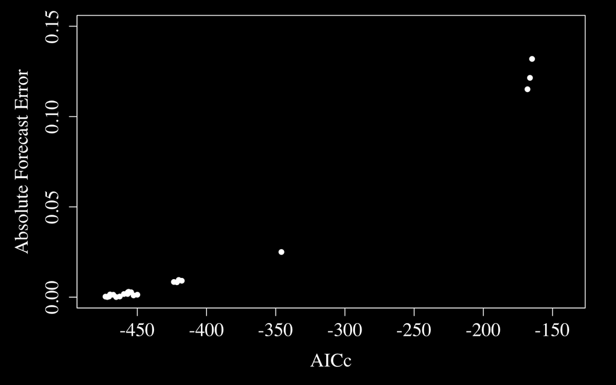

## AICc vs Forecasting Accuracy (2019q1)

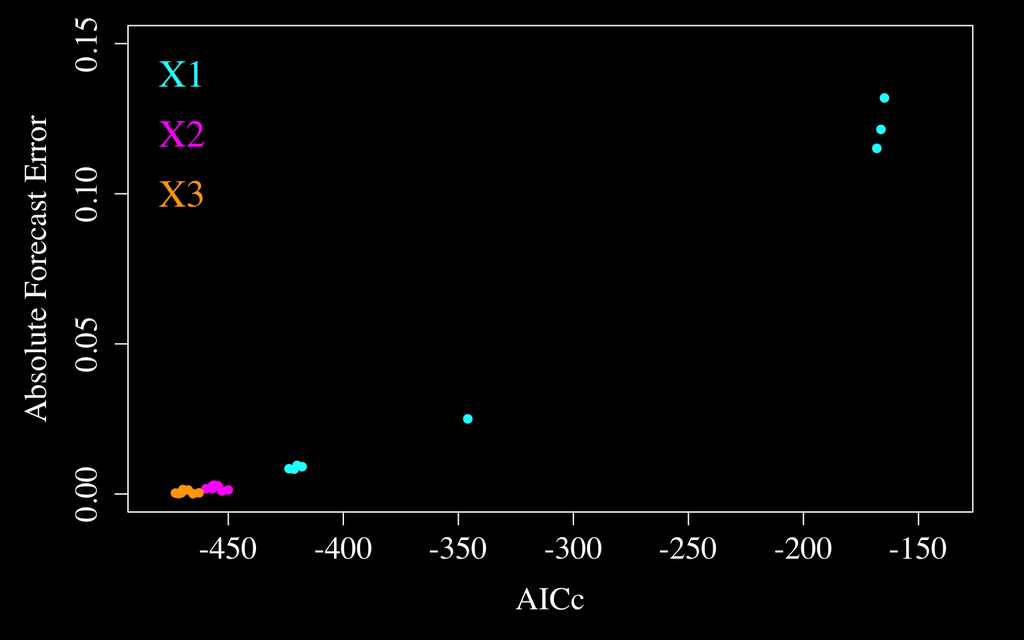

## AICc vs Forecasting Accuracy (2019q1)

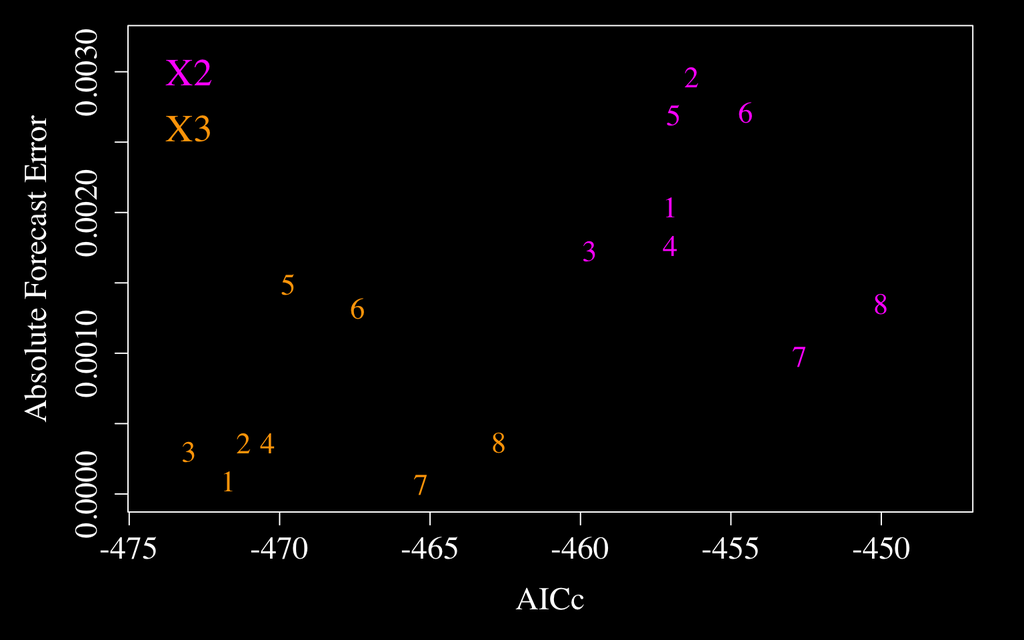

$${\textbf{Lecture 3 Summary}}$$

## Lecture 3 Summary

- Autocorrelation function describes autocorrelation properties of time series and residuals.
- The Ljung-Box autocorrelation test is used to test model residuals
- The AIC(c) is used to choose amongst forecasting models.